# Lake Water Quality Analysis

Bri Rick

2/24/2022

# LAGOS Analysis

## Loading in data

### First download and then specifically grab the locus (or site lat longs)

```r
#Lagos download script
#lagosne_get(dest_folder = LAGOSNE:::lagos_path(),overwrite=T)

#Load in lagos
lagos <- lagosne_load()


#Grab the lake centroid info
lake_centers <- lagos$locus

# Make an sf object
spatial_lakes <- st_as_sf(lake_centers,coords=c('nhd_long','nhd_lat'),
                          crs=4326)

#Grab the water quality data
nutr <- lagos$epi_nutr

#Look at column names
#names(nutr)
```

### Subset columns nutr to only keep key info that we want

```r
clarity_only <- nutr %>%
  select(lagoslakeid,sampledate,chla,doc,secchi) %>%
  mutate(sampledate = as.character(sampledate) %>% ymd(.))
```

### Keep sites with at least 200 observations

```r
#Look at the number of rows of dataset
#nrow(clarity_only)

chla_secchi <- clarity_only %>%
  filter(!is.na(chla),
         !is.na(secchi))

# How many observatiosn did we lose?
# nrow(clarity_only) - nrow(chla_secchi)


# Keep only the lakes with at least 200 observations of secchi and chla
chla_secchi_200 <- chla_secchi %>%
  group_by(lagoslakeid) %>%
  mutate(count = n()) %>%
  filter(count > 200)
```

### Join water quality data to spatial data

```r
spatial_200 <- inner_join(spatial_lakes,chla_secchi_200 %>%
                            distinct(lagoslakeid,.keep_all=T),
                          by='lagoslakeid')
```

### Mean Chl_a map

```r
### Take the mean chl_a and secchi by lake

mean_values_200 <- chla_secchi_200 %>%
  # Take summary by lake id
  group_by(lagoslakeid) %>%
  # take mean chl_a per lake id
  summarize(mean_chl = mean(chla,na.rm=T),
            mean_secchi=mean(secchi,na.rm=T)) %>%
  #Get rid of NAs
  filter(!is.na(mean_chl),
         !is.na(mean_secchi)) %>%
  # Take the log base 10 of the mean_chl
  mutate(log10_mean_chl = log10(mean_chl))

#Join datasets
mean_spatial <- inner_join(spatial_lakes,mean_values_200,
                          by='lagoslakeid')

#Make a map
mapview(mean_spatial,zcol='log10_mean_chl',map.types = c("Esri.WorldImagery", "OpenStreetMap.DE"))
```

[interactive chart not shown]

# Class work

## 1) What is the correlation between Secchi Disk Depth and Chlorophyll a for sites with at least 200 observations?

With an increase in cholorophyll, there is a decrese in Secchi Disk depth.

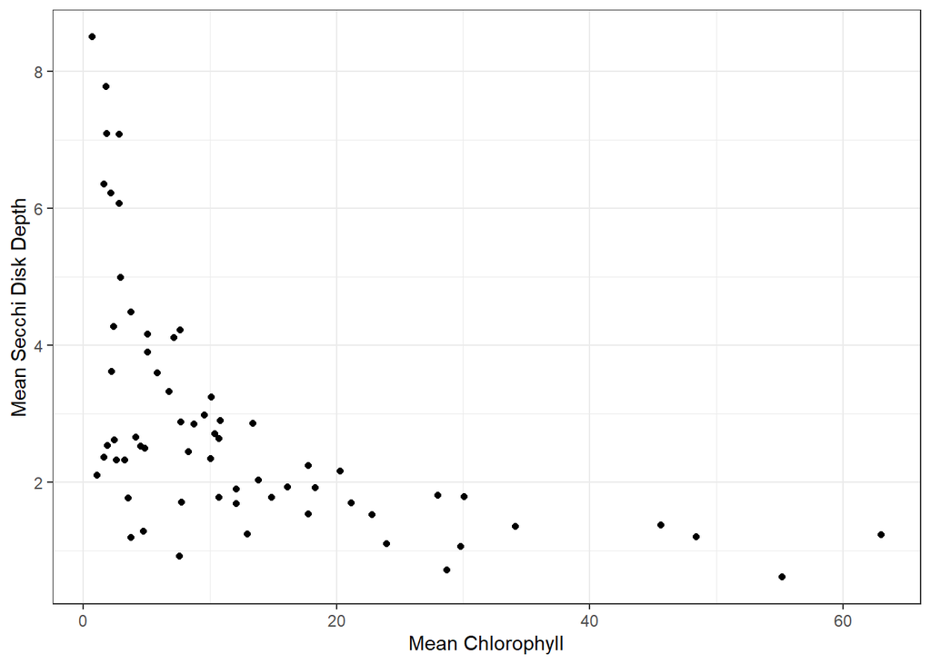

```r
#Look at distribution of mean chlorophyll vs mean secchi disk depth
ggplot(mean_spatial) +
  geom_point(aes(x = mean_chl, y = mean_secchi)) +
  xlab("Mean Chlorophyll") +
  ylab("Mean Secchi Disk Depth")+
  theme_bw()
```

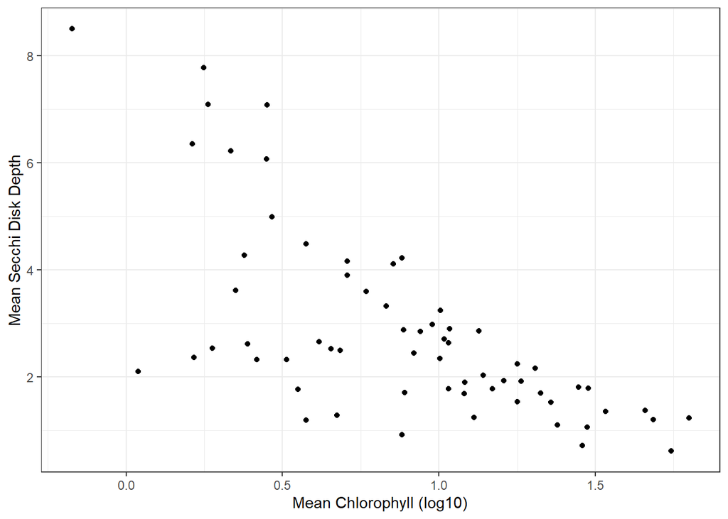

```r
#Now look at the distribution using the log 10 of mean chlorophyll
ggplot(mean_spatial) +
  geom_point(aes(x = log10_mean_chl, y = mean_secchi)) +
  xlab("Mean Chlorophyll (log10)") +
  ylab("Mean Secchi Disk Depth")+
  theme_bw()
```

## Why might this be the case?

The presence of chlorophyll is an indicator of plants, algae, or cyanobacteria, which reduce water clarity and therfore the depth at which you can see a Secchi disk.

## 2) What states have the most data?

### 2a) First you will need to make a lagos spatial dataset that has the total number of counts per site.

```r
countspersite <- lake_centers %>%
  group_by(lagoslakeid) %>%
  mutate(count = n())

stateslagos <- lagos$state %>%
  select(-state_pct_in_nwi, -state_ha_in_nwi,-state_ha)

statecounts <- inner_join(countspersite, stateslagos, by="state_zoneid")

sumstates <- statecounts %>%
  group_by(state_name) %>%
  summarize(sum_counts = sum(count))
```

### 2b) Second, you will need to join this point dataset to the us_boundaries data.

```r
states <- us_states()

counts_boundaries <- inner_join(states, sumstates, by = "state_name")

mapview(counts_boundaries, zcol = "sum_counts", map.types = c("Esri.WorldImagery", "OpenStreetMap.DE"))
```

[interactive chart not shown]

## 3) Is there a spatial pattern in Secchi disk depth for lakes with at least 200 observations?

There doesn’t appear to be an incredibly strong spatial pattern, though lakes in the northeast appear to have larger Secchi disk depths on average, which could indicate that this region has fewer algae blooms (and therefore chlorophyll which clouds the water) than the midwest.

```r
#Make a map colored by mean Secchi disk depth
mapview(mean_spatial,zcol='mean_secchi',map.types = c("Esri.WorldImagery", "OpenStreetMap.DE"))
```

[interactive chart not shown]